# Understanding Multicollinearity with Linear Regression in R

Sudheesh Sreenilayam

2025-05-12

# 1 📌 Introduction

This project explores the concept of **multicollinearity** in linear regression using synthetic data. We simulate two correlated predictors and analyze how their relationship affects model interpretation. Additionally, we inject an outlier to observe its influence on regression diagnostics.

# 2 🧪 Simulating Correlated Data

```r
set.seed(1)  # For reproducibility

# Generate independent variables
x1 <- runif(100)
x2 <- 0.5 * x1 + rnorm(100) / 10  # x2 is correlated with x1

# Create dependent variable
y <- 2 + 2 * x1 + 0.3 * x2 + rnorm(100)
```

### 2.0.1 🔍 Check Correlation Between x1 and x2

```r
cor(x1, x2)  # ~0.83 indicates high correlation
```

```
## [1] 0.8351212
```

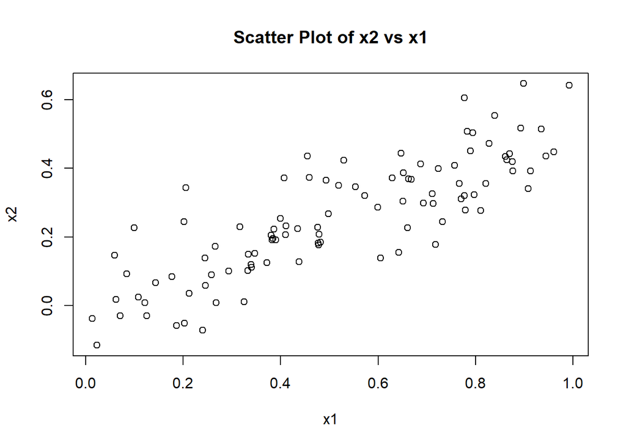

```r
plot(x2 ~ x1, main = "Scatter Plot of x2 vs x1")
```

**Interpretation:** The correlation between `x1` and `x2` is approximately 0.83, which is considered high. This confirms the presence of multicollinearity.

# 3 📉 Fitting Regression Models

## 3.1 Model 1: Multiple Linear Regression (y ~ x1 + x2)

```r
model_both <- lm(y ~ x1 + x2)
summary(model_both)
```

```
##
## Call:
## lm(formula = y ~ x1 + x2)
##
## Residuals:
##     Min      1Q  Median      3Q     Max
## -2.8311 -0.7273 -0.0537  0.6338  2.3359
##
## Coefficients:
##             Estimate Std. Error t value Pr(>|t|)
## (Intercept)   2.1305     0.2319   9.188 7.61e-15 ***
## x1            1.4396     0.7212   1.996   0.0487 *
## x2            1.0097     1.1337   0.891   0.3754
## ---
## Signif. codes:  0 '***' 0.001 '**' 0.01 '*' 0.05 '.' 0.1 ' ' 1
##
## Residual standard error: 1.056 on 97 degrees of freedom
## Multiple R-squared:  0.2088, Adjusted R-squared:  0.1925
## F-statistic:  12.8 on 2 and 97 DF,  p-value: 1.164e-05
```

## 3.2 Model 2: Simple Regression (y ~ x1)

```r
model_x1 <- lm(y ~ x1)
summary(model_x1)
```

```
##
## Call:
## lm(formula = y ~ x1)
##
## Residuals:
##      Min       1Q   Median       3Q      Max
## -2.89495 -0.66874 -0.07785  0.59221  2.45560
##
## Coefficients:
##             Estimate Std. Error t value Pr(>|t|)
## (Intercept)   2.1124     0.2307   9.155 8.27e-15 ***
## x1            1.9759     0.3963   4.986 2.66e-06 ***
## ---
## Signif. codes:  0 '***' 0.001 '**' 0.01 '*' 0.05 '.' 0.1 ' ' 1
##
## Residual standard error: 1.055 on 98 degrees of freedom
## Multiple R-squared:  0.2024, Adjusted R-squared:  0.1942
## F-statistic: 24.86 on 1 and 98 DF,  p-value: 2.661e-06
```

## 3.3 Model 3: Simple Regression (y ~ x2)

```r
model_x2 <- lm(y ~ x2)
summary(model_x2)
```

```
##
## Call:
## lm(formula = y ~ x2)
##
## Residuals:
##      Min       1Q   Median       3Q      Max
## -2.62687 -0.75156 -0.03598  0.72383  2.44890
##
## Coefficients:
##             Estimate Std. Error t value Pr(>|t|)
## (Intercept)   2.3899     0.1949   12.26  < 2e-16 ***
## x2            2.8996     0.6330    4.58 1.37e-05 ***
## ---
## Signif. codes:  0 '***' 0.001 '**' 0.01 '*' 0.05 '.' 0.1 ' ' 1
##
## Residual standard error: 1.072 on 98 degrees of freedom
## Multiple R-squared:  0.1763, Adjusted R-squared:  0.1679
## F-statistic: 20.98 on 1 and 98 DF,  p-value: 1.366e-05
```

**Interpretation:**

- In the multiple regression model (`y ~ x1 + x2`), `x1` is significant but `x2` is not.
- In the individual models, both `x1` and `x2` show significance.
- This demonstrates the effect of **multicollinearity**, where the shared information between predictors causes one to appear insignificant.

# 4 ⚠️ Adding an Outlier and Rerunning Models

```r
x1 <- c(x1, 0.1)
x2 <- c(x2, 0.8)
y <- c(y, 6)

# Refit models with outlier
model_both_outlier <- lm(y ~ x1 + x2)
model_x1_outlier <- lm(y ~ x1)
model_x2_outlier <- lm(y ~ x2)
```

# 5 🔍 Diagnostic Plots for Outlier Impact

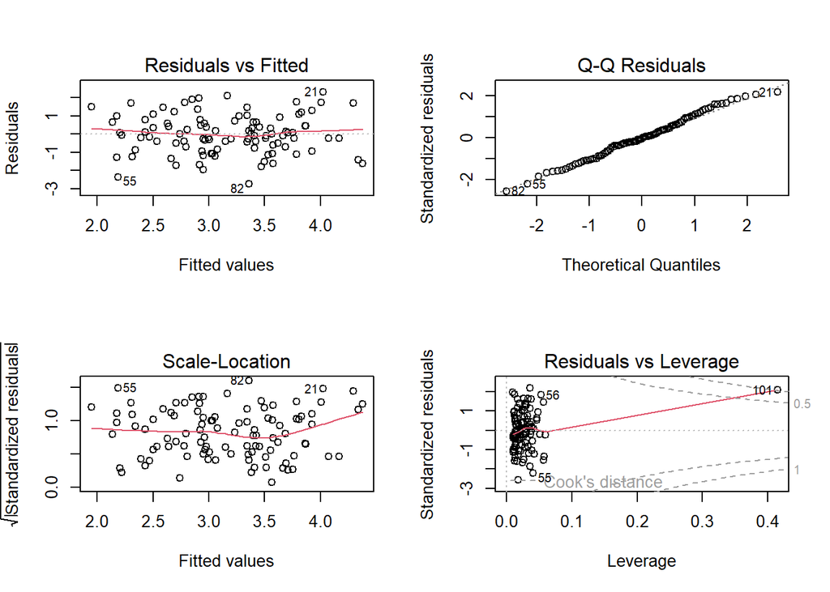

```r
par(mfrow = c(2, 2))
plot(model_both_outlier)
```

# 6 🧾 Conclusion

This project demonstrates:

- How **correlated predictors** affect coefficient interpretation in linear regression
- The importance of checking for **multicollinearity** before trusting model significance levels
- How **diagnostic plots** can reveal issues like high-leverage points or outliers

This kind of analysis is critical when building real-world predictive models to ensure reliability and interpretability.